# Red Wine Quality Exploration By Anu Achankunju

# ========================================================

## Summary Statistics

### What is the structure of your dataset?

Let’s run some basic functions to examine the structure and schema of the data set.

Below table shows the dimension of the Red wine data frame in the format nrow X ncols

```
## [1] 1599   13
```

The below table shows the different columns of the Red Wine date frame.

```
##  [1] "X"                    "fixed.acidity"        "volatile.acidity"
##  [4] "citric.acid"          "residual.sugar"       "chlorides"
##  [7] "free.sulfur.dioxide"  "total.sulfur.dioxide" "density"
## [10] "pH"                   "sulphates"            "alcohol"
## [13] "quality"
```

The below table shows the Red Wine data frame summary along with the basic statistics of each column in the data frame.

```
##        X          fixed.acidity   volatile.acidity  citric.acid
##  Min.   :   1.0   Min.   : 4.60   Min.   :0.1200   Min.   :0.000
##  1st Qu.: 400.5   1st Qu.: 7.10   1st Qu.:0.3900   1st Qu.:0.090
##  Median : 800.0   Median : 7.90   Median :0.5200   Median :0.260
##  Mean   : 800.0   Mean   : 8.32   Mean   :0.5278   Mean   :0.271
##  3rd Qu.:1199.5   3rd Qu.: 9.20   3rd Qu.:0.6400   3rd Qu.:0.420
##  Max.   :1599.0   Max.   :15.90   Max.   :1.5800   Max.   :1.000
##  residual.sugar     chlorides       free.sulfur.dioxide
##  Min.   : 0.900   Min.   :0.01200   Min.   : 1.00
##  1st Qu.: 1.900   1st Qu.:0.07000   1st Qu.: 7.00
##  Median : 2.200   Median :0.07900   Median :14.00
##  Mean   : 2.539   Mean   :0.08747   Mean   :15.87
##  3rd Qu.: 2.600   3rd Qu.:0.09000   3rd Qu.:21.00
##  Max.   :15.500   Max.   :0.61100   Max.   :72.00
##  total.sulfur.dioxide    density             pH          sulphates
##  Min.   :  6.00       Min.   :0.9901   Min.   :2.740   Min.   :0.3300
##  1st Qu.: 22.00       1st Qu.:0.9956   1st Qu.:3.210   1st Qu.:0.5500
##  Median : 38.00       Median :0.9968   Median :3.310   Median :0.6200
##  Mean   : 46.47       Mean   :0.9967   Mean   :3.311   Mean   :0.6581
##  3rd Qu.: 62.00       3rd Qu.:0.9978   3rd Qu.:3.400   3rd Qu.:0.7300
##  Max.   :289.00       Max.   :1.0037   Max.   :4.010   Max.   :2.0000
##     alcohol         quality
##  Min.   : 8.40   Min.   :3.000
##  1st Qu.: 9.50   1st Qu.:5.000
##  Median :10.20   Median :6.000
##  Mean   :10.42   Mean   :5.636
##  3rd Qu.:11.10   3rd Qu.:6.000
##  Max.   :14.90   Max.   :8.000
```

The below table shows the internal structure of Red Wine data frame.

```
## 'data.frame':    1599 obs. of  13 variables:
##  $ X                   : int  1 2 3 4 5 6 7 8 9 10 ...
##  $ fixed.acidity       : num  7.4 7.8 7.8 11.2 7.4 7.4 7.9 7.3 7.8 7.5 ...
##  $ volatile.acidity    : num  0.7 0.88 0.76 0.28 0.7 0.66 0.6 0.65 0.58 0.5 ...
##  $ citric.acid         : num  0 0 0.04 0.56 0 0 0.06 0 0.02 0.36 ...
##  $ residual.sugar      : num  1.9 2.6 2.3 1.9 1.9 1.8 1.6 1.2 2 6.1 ...
##  $ chlorides           : num  0.076 0.098 0.092 0.075 0.076 0.075 0.069 0.065 0.073 0.071 ...
##  $ free.sulfur.dioxide : num  11 25 15 17 11 13 15 15 9 17 ...
##  $ total.sulfur.dioxide: num  34 67 54 60 34 40 59 21 18 102 ...
##  $ density             : num  0.998 0.997 0.997 0.998 0.998 ...
##  $ pH                  : num  3.51 3.2 3.26 3.16 3.51 3.51 3.3 3.39 3.36 3.35 ...
##  $ sulphates           : num  0.56 0.68 0.65 0.58 0.56 0.56 0.46 0.47 0.57 0.8 ...
##  $ alcohol             : num  9.4 9.8 9.8 9.8 9.4 9.4 9.4 10 9.5 10.5 ...
##  $ quality             : int  5 5 5 6 5 5 5 7 7 5 ...
```

Some initial observations are:

- There are 1599 observations of 13 numeric variables.
- **X** appears to be the unique identifier.
- **Quality** is an ordered, categorical, discrete variable. From the literature, this was on a 0-10 scale, and was rated by at least 3 wine experts.
- All other variables seem to be continuous numeric values.
- From the variable descriptions, it appears that fixed.acidity, ~ volatile.acidity and free.sulfur.dioxide ~ total.sulfur.dioxide may possible by dependent, subsets of each other.

### What is/are the main feature(s) of interest in your dataset?

We are primarily interested in the feature **Quality** .It would be interesting to see basic statistics on quality as well. Below table shows the basis statistics of feature quality.

```
##    Min. 1st Qu.  Median    Mean 3rd Qu.    Max.
##   3.000   5.000   6.000   5.636   6.000   8.000
```

Most wines have quality score of 5 or 6. The lowest quality is 3, and the highest is 8. The mean alcohol is 10.42, the median of alcohol is 10.20.

Let’s table the feature quality.

```
##
##   3   4   5   6   7   8
##  10  53 681 638 199  18
```

Assertion was correct here, so let’s ensure the data frame semantically reflects that.

```
##  Ord.factor w/ 6 levels "3"<"4"<"5"<"6"<..: 3 3 3 4 3 3 3 5 5 3 ...
```

## Univariate Plots

To first explore this data visually, histograms of all 12 variables are plotted to see the distribution of their values.

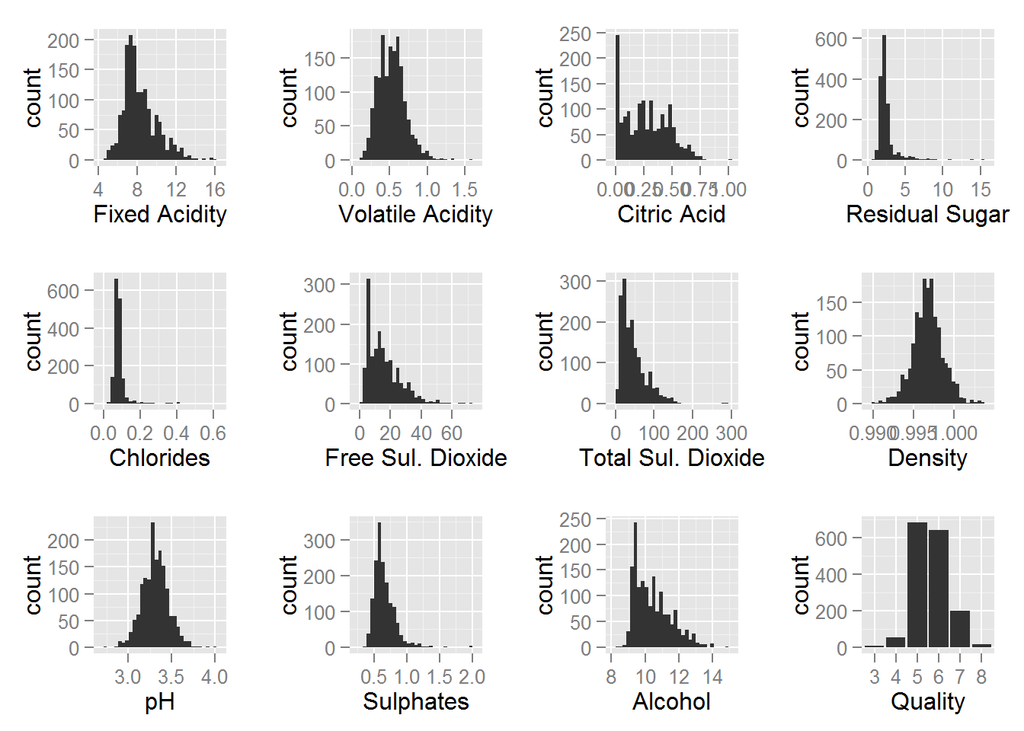

## Univariate Analysis

#### Wine Quality

The wine quality score is spread between 3 and 8 for the 1599 observations with most of the scores at 5 or 6.Although it has a discrete range of only 3-8, we can roughly see that there is some amount of normal distribution. There’s not much more we can do with this histogram, as both decreasing or increasing bin sizes would distort the data.

Given the ratings and distribution of wine quality, another categorical variable is instantiated, classifying the wines as ‘bad’ (rating 0 to 4), ‘average’ (rating 5 or 6), and ‘good’ (rating 7 to 10).

```
##  Bad  Avg Good
##   63 1319  217
```

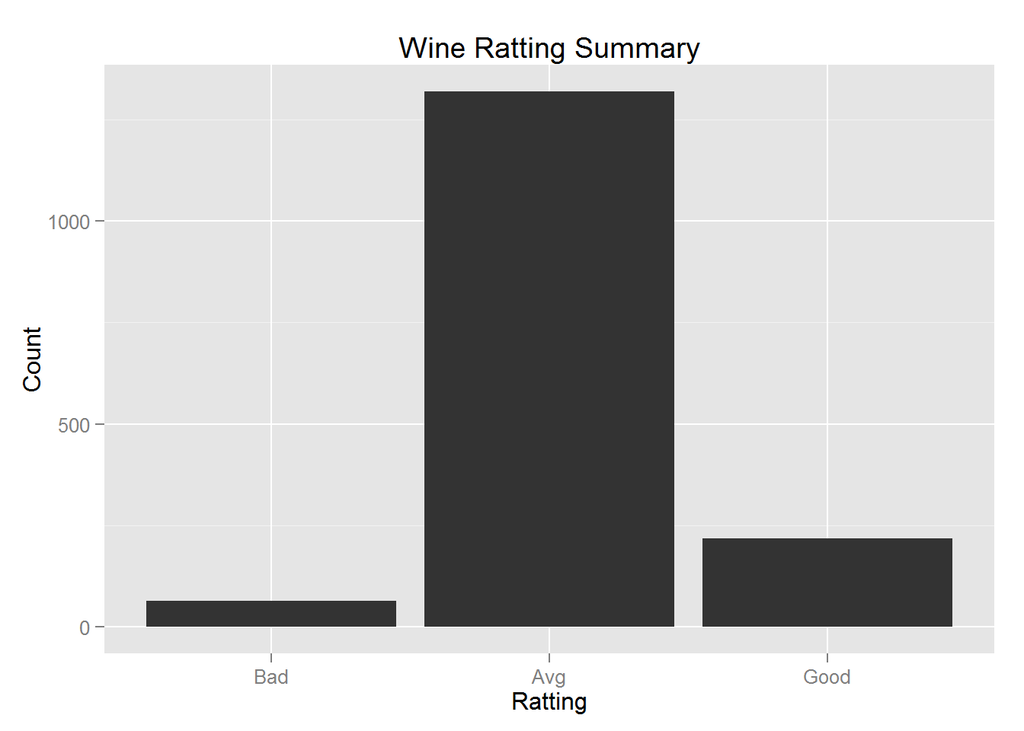

### Distributions and Outliers

- It appears that density and pH are normally distributed, with few outliers.
- Fixed and volatile acidity, sulfur dioxides, sulphates, and alcohol seem to be long-tailed.
- Qualitatively, residual sugar and chlorides have extreme outliers.
- Citric acid appeared to have a large number of zero values. I’m curious whether this is truly zero, or if it is a case of non-reporting.

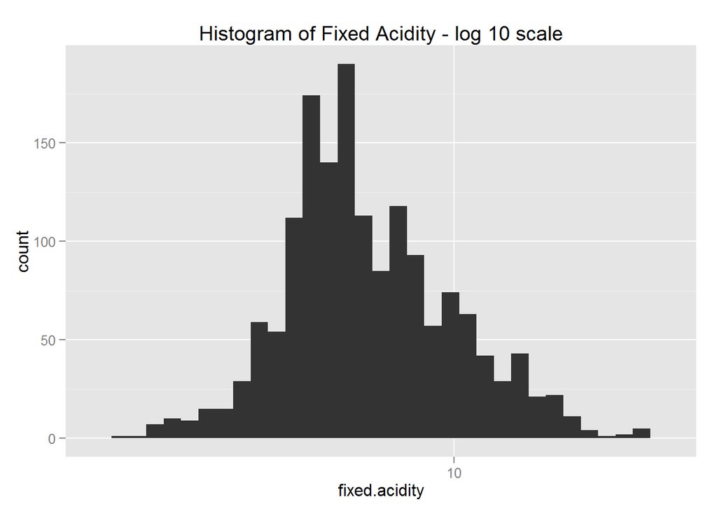

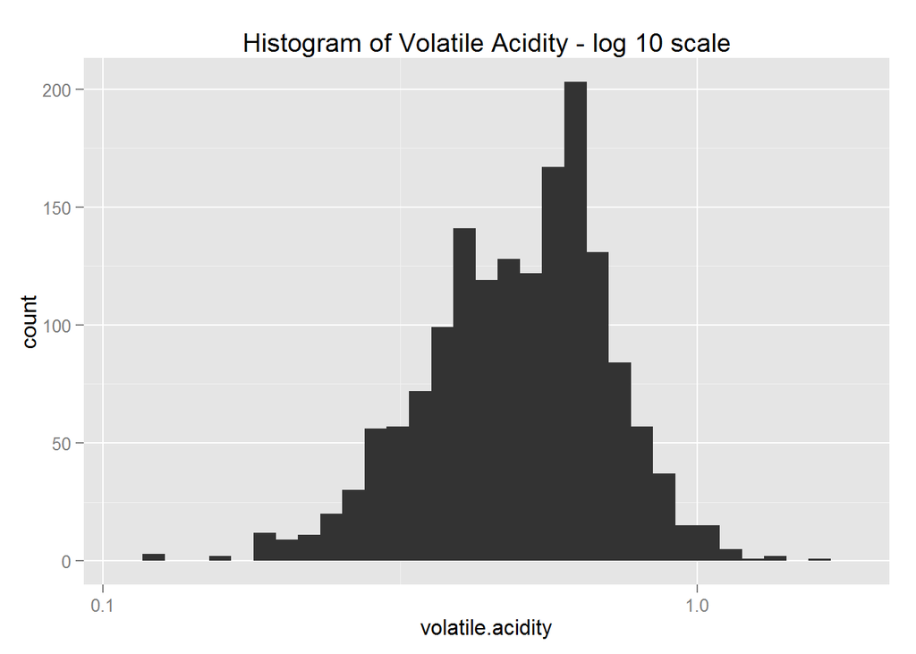

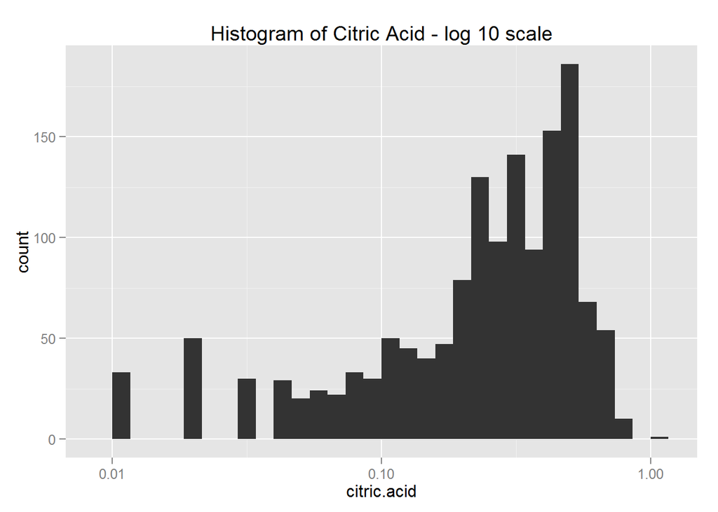

When plotted on a base 10 logarithmic scale, fixed.acidity and volatile.acidity appear to be normally-distributed. This makes sense, considering that pH is normally distributed, and pH, by definition, is a measure of acidity and is on a logarithmic scale. Curiously, however, citric.acid, did not appear to be normally-distributed on a logarithmic scale. Upon further investigation as shown in below table

```
## [1] 132
```

It is apparent that 132 observations had a value of zero. This yields some concerns on whether or not these 132 values were reported or not, considering that the next ‘bin’ higher contains only 32 observations.

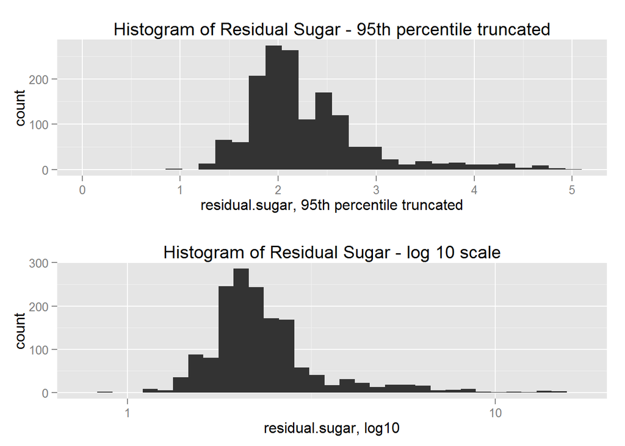

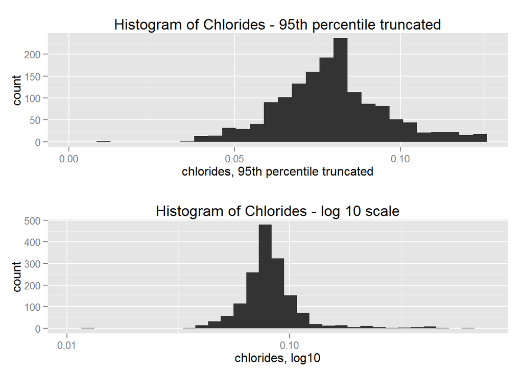

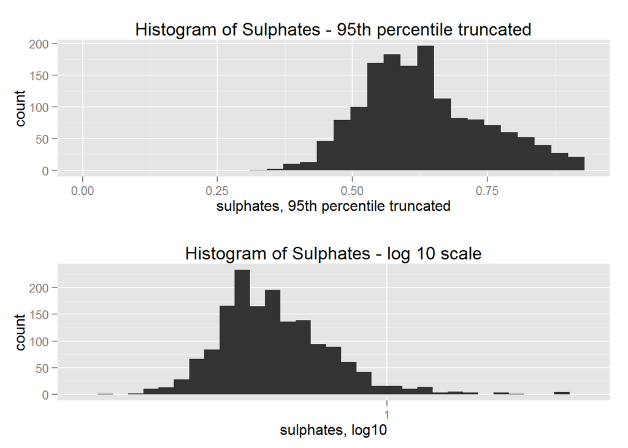

## Short questions

### What other features in the dataset do you think will help support your investigation into your feature(s) of interest?

While exploring the univariate histogram distributions, there did not appear to be any bimodal or multimodal distributions that would warrant sub-classification into categorical variables. Hence I don’t think we have any other feature left for investigation.

### Did you create any new variables from existing variables in the dataset?

Instantiated an ordered factor, rating, classifying each wine sample as ‘bad’, ‘average’, or ‘good’.

Upon further examination of the data set documentation, it appears that fixed.acidity and volatile.acidity are different types of acids; tartaric acid and acetic acid. I decided to create a combined variable, TAC.acidity, containing the sum of tartaric, acetic, and citric acid.

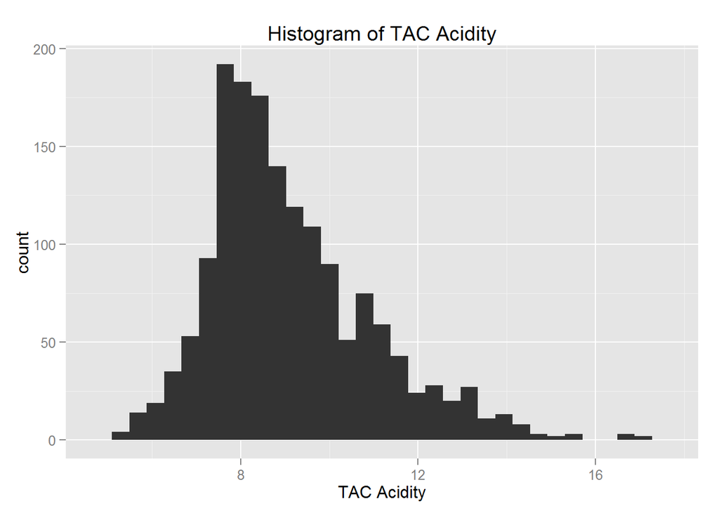

### Of the features you investigated, were there any unusual distributions?Did you perform any operations on the data to tidy, adjust, or change the form of the data? If so, why did you do this?

I addressed the distributions in the ‘Distributions’ section. Boxplots are better suited in visualizing the outliers.

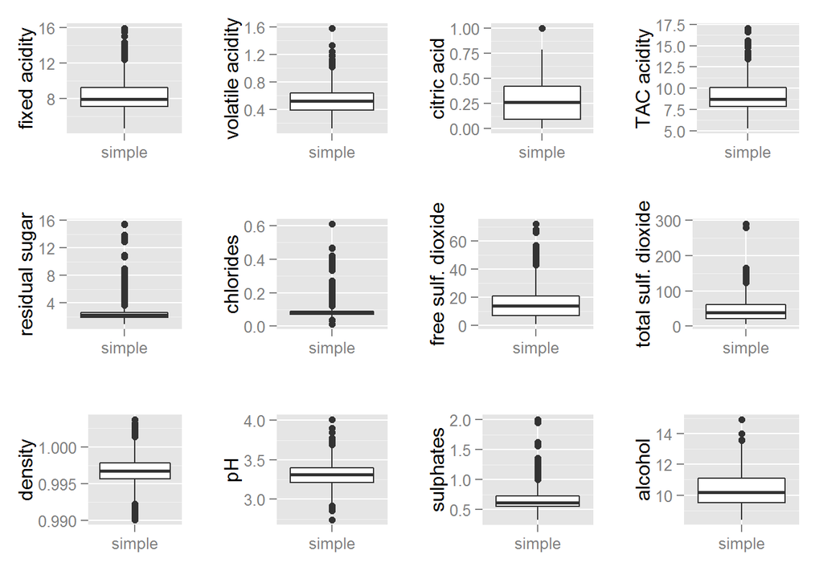

In univariate analysis, I chose not to tidy or adjust any data, short of plotting a select few on logarithmic scales. Bivariate boxplots, with X as rating or quality, will be more interesting in showing trends with wine quality.

## Bivariate Plots

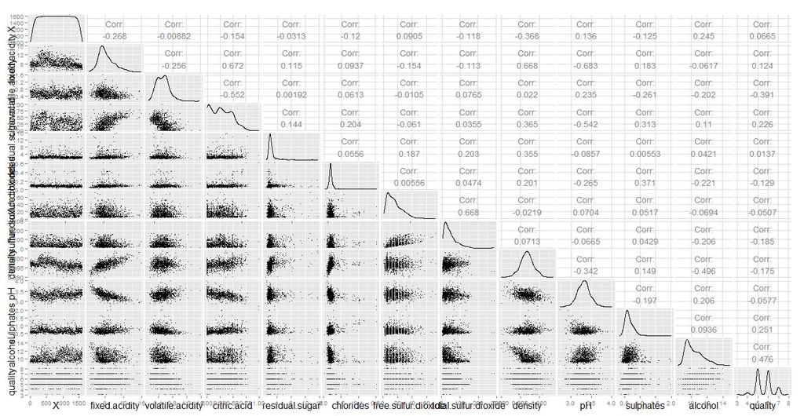

Based on the ggpair above, I decided to have a look at bivariate plots with the 4 most correlated variables with quality in order to have a deeper look into the relationships.

For each bivariate plot , in order to focus on the correlation, I decided to include:

- A boxplot of the variable depending on quality
- Median line

### Relationship between Quality and 4 highest correlated variables

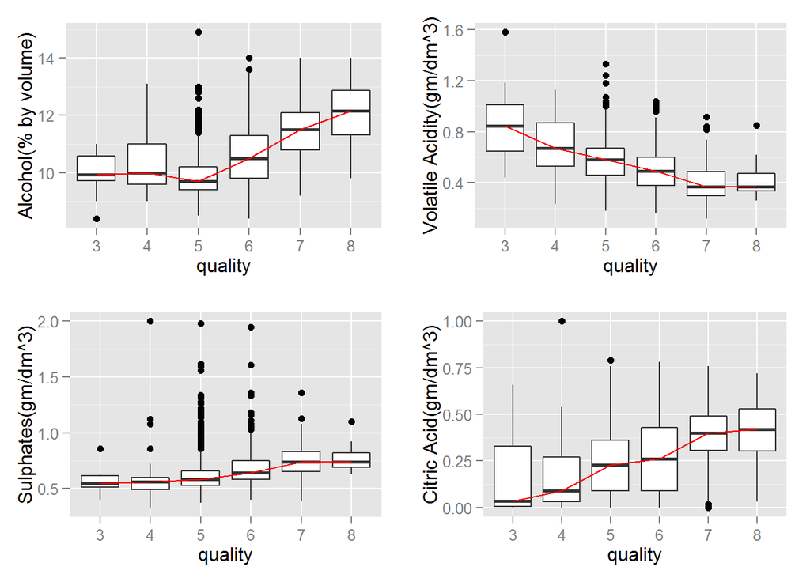

The left graph below shows the relationship between the fixed acidity level and density. Through the smooth line, we can see that there’s a positive correlation as fixed acidity level is increased density increases.

The right graph below shows the density/alcohol relationship between which is the opposite to the fixed acidity/density relationship. In this case the highest the density is, the lowest the degree of alcohol is, this is in fact called an anti-correlation (negative correlation)

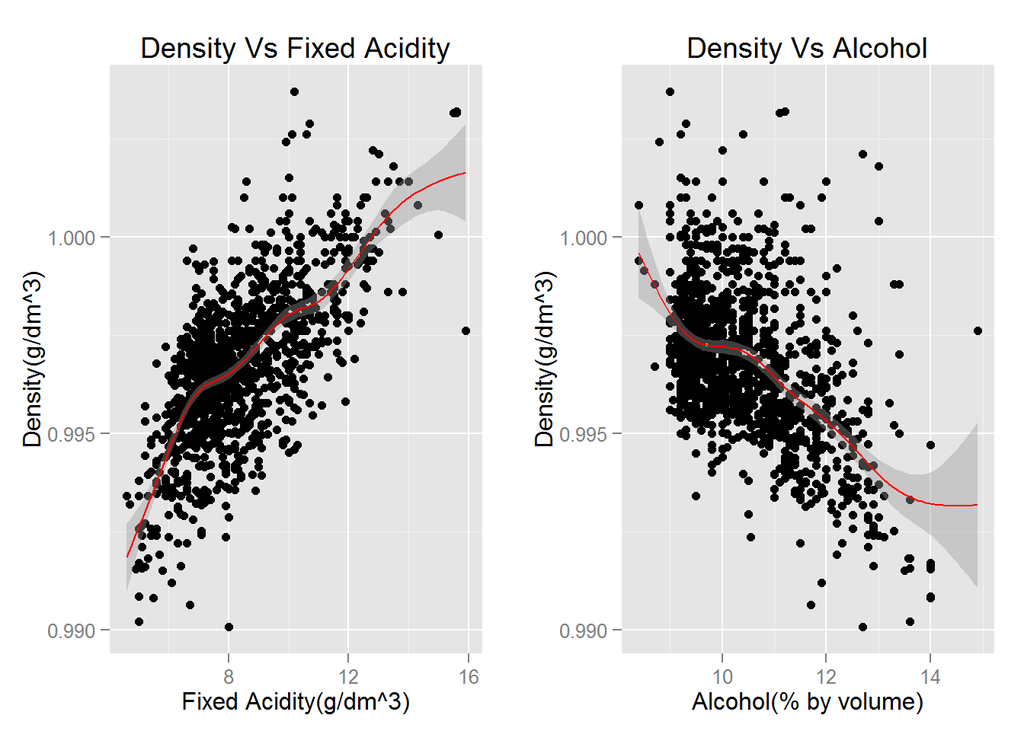

## Bivariate Analysis

#### Talk about some of the relationships you observed in this part of the investigation. How did the feature(s) of interest vary with other features in the dataset?

In order to start the investigation, I initiated a ggpair so I could have a look at the correlation coefficients between varibales but also at the automated plots in case I could identify some interesting distributions.

I had no real expectations with regards to the impact of other variables on the quality, however I was somehow surprised with some of the findings. With the limited dataset that we have on red wines, there are many variables which are significantly correlated to the quality of wine. You can find below the list of variables with their corresponding correlation coefficient (I excluded coefficients close to 0) :

**Positive Correlation**

- Alcohol: 0.476
- Sulphates: 0.251
- Citric Acid: 0.226
- Fixed Acidity: 0.124

**Negative Correlation**

- Volatile Acidity: -0.391
- Total SO2: -0.185
- Density: -0.175
- Chlorides: -0.129

I also found an interesting relationship with one of the remaining variables (Free Sulfur Dioxide) which had not a significant correlation coefficient with the quality. Looking at the ggpair plot, it seemed to be very close to a normal distribution. This would mean that the lowest the variable can be, the higher chance is to find either a bad or a good rating. If the variable is high, there’s a higher probability that the quality is average.

You can observe it by looking at the median line across the quality of wine on the graph below (I used the geom_jitter in order to have a better looking plot):

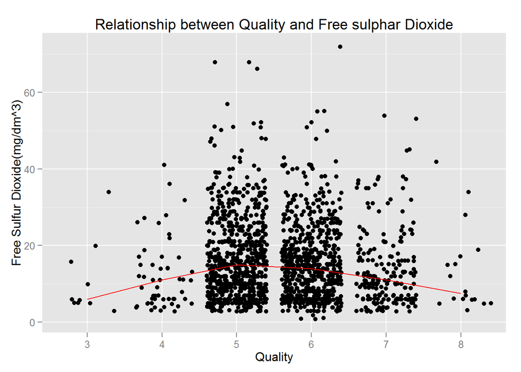

#### Did you observe any interesting relationships between the other features (not the main feature(s) of interest)?

First one that came to mind was the relationship between Chlorides and Residual Sugar as you can see below. I am not sure how to consider the observations which are on the top-left-hand corner and the ones on the bottom-right-hand corner. Would they be considered as outliers or related to the limited data available for red wines with more than 4 mg/L of residual sugars OR more than 0.2 mg/L of chlorides

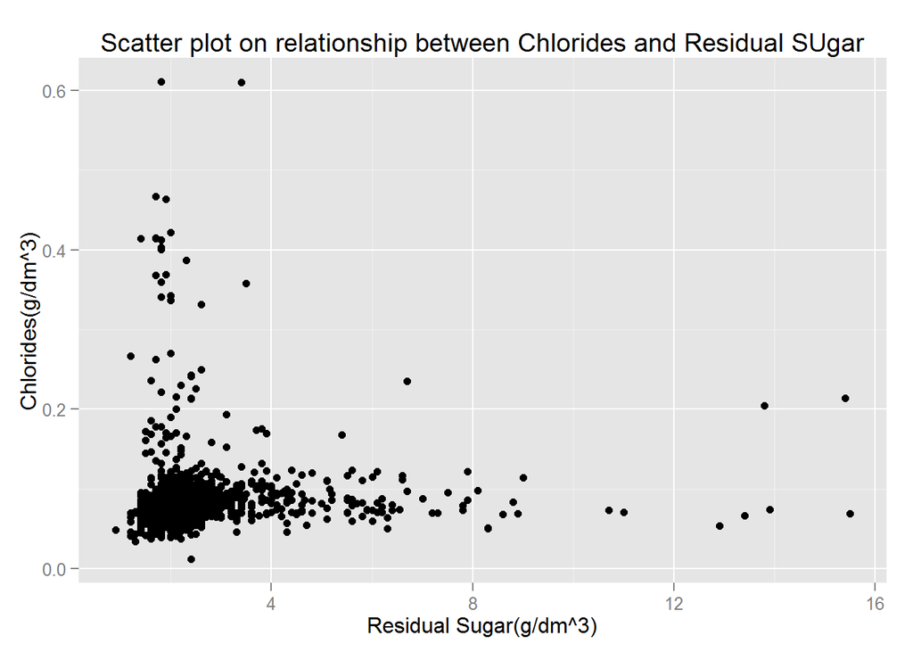

It is actually quite interesting to see the behavior of Chlorides as they always seem to come up with interesting scatter plots similar to the one above. You can see below another scatter plot with Chlorides, but this time with Density. There seems to be a linear distribution, however the Chlorides are surprisingly high between density .995 and 1. Perhaps more investigation towards the general behavior of Chlorides might be a next step in order to understand how it develops unevenly in certain conditions. It might also be linked to a different type of wine which is part of the dataset, however, as we don’t have information about the grapes, year, producer, we can’t find any information about the nature of the wine and why only a dozen of observations have high level of Chlorides.

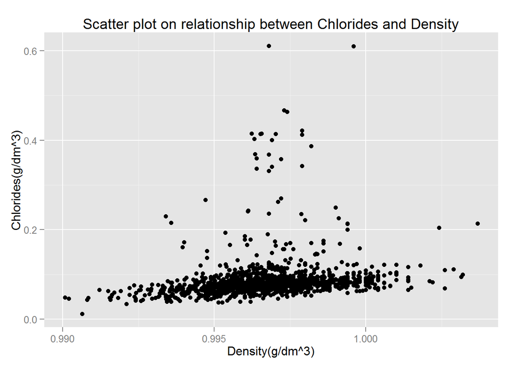

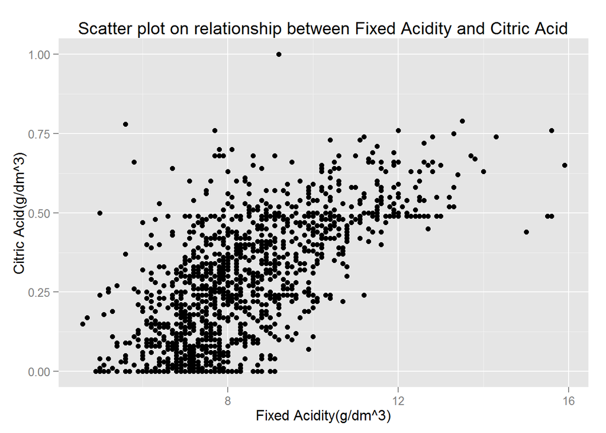

#### What was the strongest relationship you found?

The most interesting relationship was pH over Fixed Acidity as it came up with a correlation coefficient of -0.683. You can find below the scatterplot to illustrate this relationship

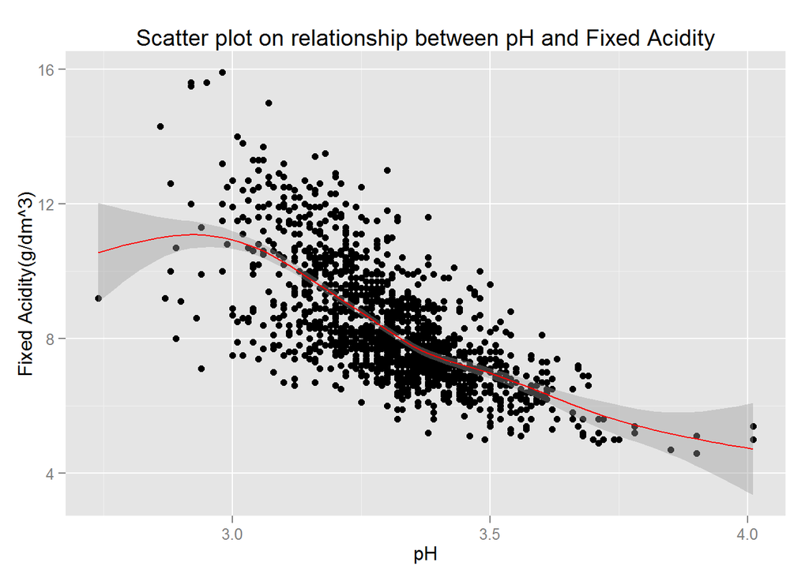

## Multivariate Plots

As seen in the section above, we were able to identify the highest correlation coefficients between quality and the other variables available in our dataset. In order to see if there was some interesting relationship through a multivariate plot, I decided to have a look at each of the bivariate scatterplot with other variables. In order to focus on my feature of interest (quality), I colored each point with its related score.

I found several plots which were somehow relevant and have been listing them below. The legend on the right indicates the color for each score. The other variables involved in the plots below are :

Volatile Acidity Citric acid Alcohol Sulphates pH

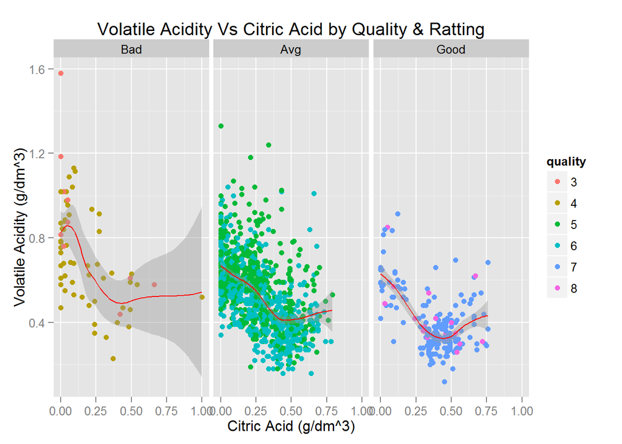

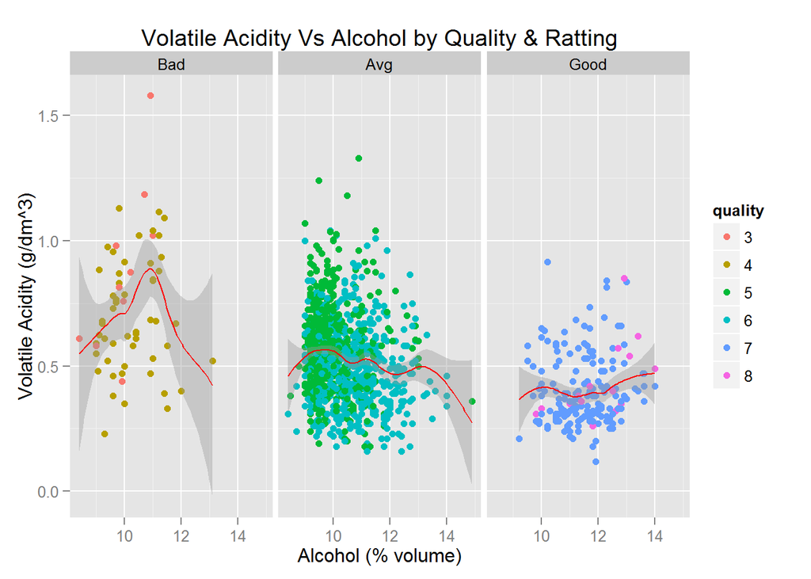

[figure not shown]

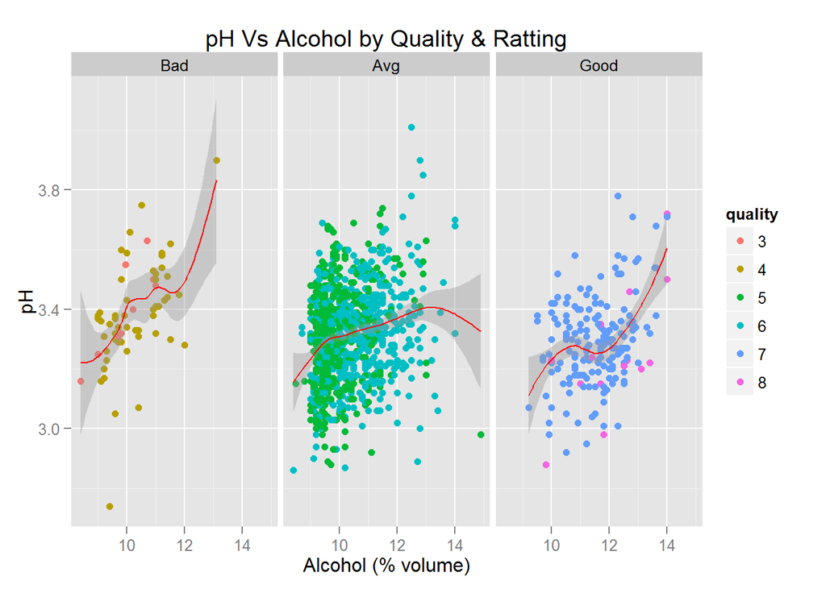

## Multivariate Analysis

I primarily examined the 4 features which showed high correlation with quality. These scatterplots were a bit crowded, so I faceted by rating to illustrate the population differences between good wines, average wines, and bad wines.While looking at the multivariate plots, it became evident that Alcohol was clearly the stronger feature to impact the quality of the wine.

It’s clear that a higher citric acid and lower volatile (acetic) acid contributes towards better wines. Likewise, better wines tended to have higher sulphates and alcohol content. Interestingly, this shows that what makes a good wine depends on the type of acids that are present.

The most interesting plot in order to see the strengthening of features, was the one including the 2 highest correlation coefficient : Alcohol and Volatile Acidity. For all the other plots, a different analysis could have been made as we could see a trend appearing when comparing the lowest and highest scores, however the average scores tend to not follow this trend.

In my quest to find which features were most impacting the quality of the wine, I found that it was difficult to find one approach that would specify easily and quickly if a wine would be a 3, a 5 or an 8. However, through the many different generated plots, it became evident that some relationships can highlight if a wine is likely to be high or likely to be low, however there’s too much observations “in the middle” to be able to know if a wine is going to be a 5 or a 6 (which I consider as average score).

I made one of those different identifications for almost each of the multivariate plots :

- Trend appearing across all scores
- Despite identifying a trend in the scores, the observations for score 5 were not following it (mostly close to scores 3-4)

## Final Plots and Summary

### Plot 1: Effect of acids on wine quality

The below plot explains the relationship between wine quality and diffrent types of acid contents.

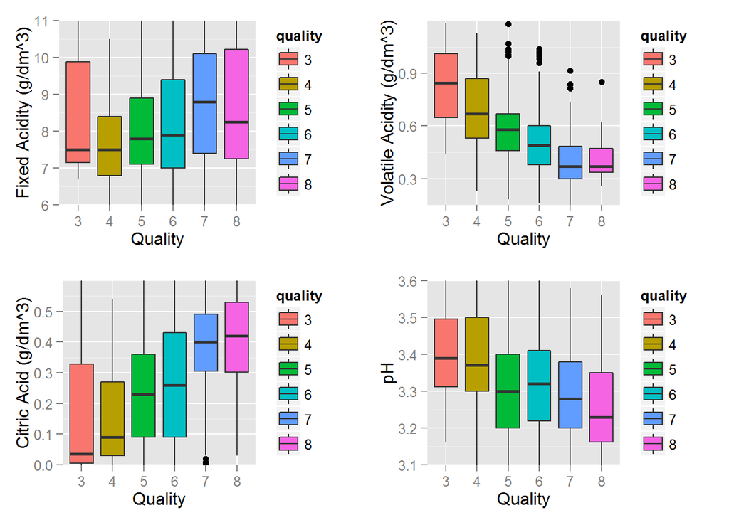

These subplots were created to demonstrate the effect of acidity and pH on wine quality.

#### Plot 1: Description

Here are the conclusions from the above plot:

- Generally, higher acidity (or lower pH) is seen in highly-rated wines.
- Presence of volatile (acetic) acid negatively affected wine quality.
- Citric acidity had a high correlation with wine quality
- fixed(tartaric) acid had a smaller impact on the wine quality.

### Plot 2: Effect of Alcohol on Wine Quality

The below plot explains the relationship between wine quality and Alchohol

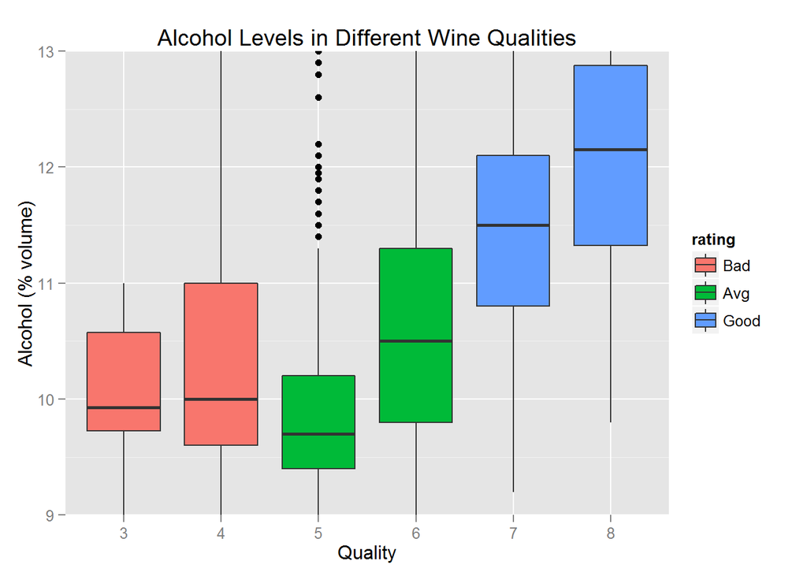

### Plot 3: What makes good wines, good, and bad wines, bad?

The below plot explains the relationship between volatile acidity and alcohol content in good and bad wines.

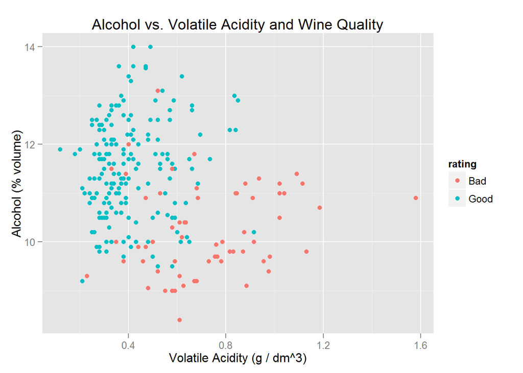

#### Plot 3: Description

This is perhaps the most telling graph. I subsetted the data to remove the ‘average’ wines, or any wine with a rating of 5 or 6. As the correlation tests show, wine quality was affected most strongly by alcohol and volaticle acidity. While the boundaries are not as clear cut or modal, it’s apparent that high volatile acidity–with few exceptions–kept wine quality down. Hence we can conclude that **A combination of high alcohol content and low volatile acidity produces better wines.**

## Reflection

Through this exploratory data analysis, I was able to identify the key factors that determine and drive wine quality, mainly: alcohol content, sulphates, and acidity. It is important to note, however, that wine quality is ultimately a subjective measure, albeit measured by wine experts. That said, the correlations for these variables are within reasonable bounds. The graphs adequately illustrate the factors that make good wines ‘good’ and bad wines ‘bad’. Further study with inferential statistics could be done to quantitatively confirm these assertions.

#### Struggles

I still believe that, with more data available, I would be able to do a better analysis as there’s a lot of impactful data that were not available in this dataset such as :

- Types of Grape
- Year
- Producer
- Region
- Aging

All of those factors above are supposed to impact the quality of the wine based on my experience but also from different articles I’ve been able to read throughout the years.

#### Successes

Nevertheless, it is interesting to realize that you can still judge a wine quality (to some extent) with very technical variables without the need to actually taste it. It must provide the wine maker some sort of guidance towards how to produce a better wine. From the highest correlation coefficient, we can see that Alcohol plays a big part, therefore the wine makers must try to find techniques in order to increase the alcohol degree towards 14 and also decrease the volatile acidity (negative correlation). By looking in the Wine fermentation process, you realize that volatile acidity appears following oxydation during the fermentation process etc.

To sum it up, the wine fermentation is a process that plays a lot in the quality of the wine and also the reason why wine makers pay a particular attention to this process as it can make a big success or a big failure. Wine is not only made out of grapes, it is a chemical process which needs to be followed very strictly in order to avoid bad surprises. So after all, while there might be some data missing, we still have all the information available to predict a potential outcome.

On top of this fermentation process, the judgment of the wine experts can also contains uncertainty, as they may all have slightly different criteria when judging a wine. I do not believe that one expert will mark a wine as 3 and another expert the same wine at 8, but I still think that there might be some variations which can lead to different scores. This is actually probably the reason that the outcome of the dataset is measured as the median of 3 different wine expert score. While Enology (study of the wine) guides all wine experts, I still firmly believe that a specific wine may be perceived differently from one palate to the other, so it is not an exact science.